# Negro league eligible population

Shen Yan, Adrian Burgos Jr., Christopher Kinson, and Daniel J. Eck

In this document we estimate the Negro League eligible population factoring in the changing levels of interest in the game.

Negro League Baseball started as a game played by people largely from the South region of the United States of America. Our construction of the Negro League eligible population will be pegged to the population of age 20-29 males from the South region of the United States of America from 1920 to 1948. Simply stated, the Negro League eligible population will be

$$\frac{\text{South region population} \times \text{percent of age 20 to
29 negro males}}{\text{proportion of negro league players from South
region}} \times \text{adjustment}.$$

In our analysis, the states that comprise the South region are:

We load in the necessary software packages used in this analysis.

```r
library(Lahman)
library(tidyverse)
library(ggplot2)
library(splines)
```

## MLB Demographics

We load in the Batting and Pitching data sets scrapped from the [Baseball-Reference](https://www.baseball-reference.com/) and isolate the birth state and birth country for every Negro League player in history. Missing entries are discarded.

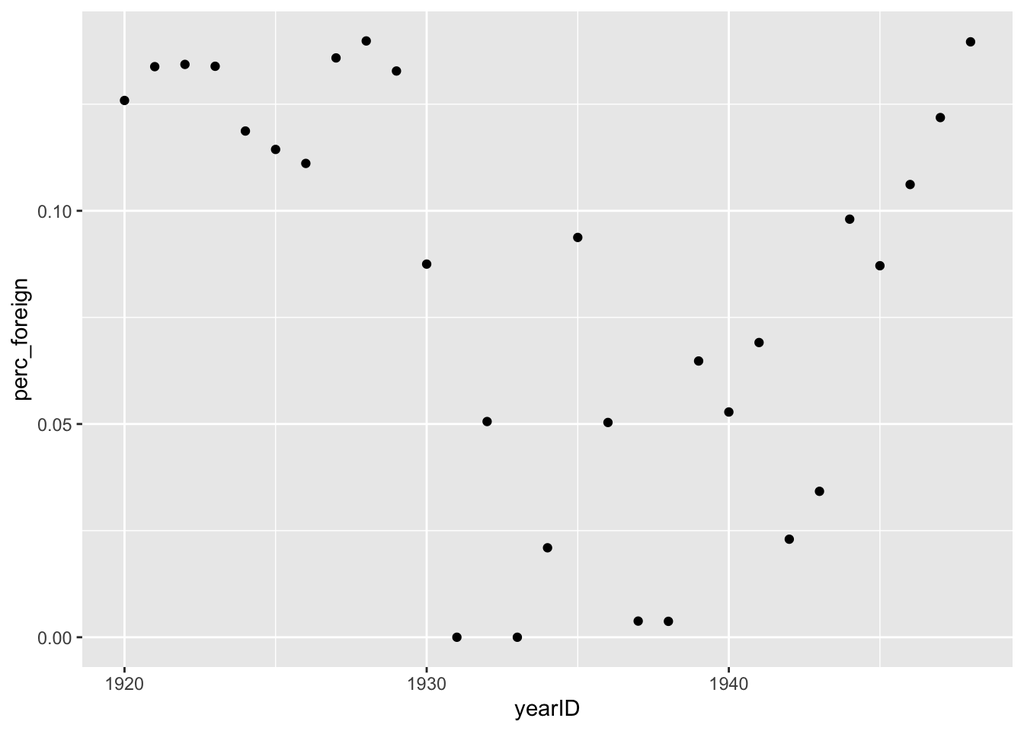

```r
# Negro League Demographics

negro_info <- read.csv("negro_info.csv")
negro_bat_all <- read.csv("bat_negro_all.csv")
negro_pit_all <- read.csv("pit_negro_all.csv")

foo_bat <- negro_bat_all %>% dplyr::select(playerID, yearID) %>%
  left_join(negro_info %>% dplyr::select(playerID, state, country))
foo_pit <- negro_pit_all %>% dplyr::select(playerID, yearID) %>%
  left_join(negro_info %>% dplyr::select(playerID, state, country))

foo_tot <- rbind(foo_bat, foo_pit) %>% distinct()

## throw out missing entries
foo_tot <- foo_tot[!is.na(foo_tot$country), ]
foo_tot <- foo_tot[foo_tot$playerID != 'binghbi01', ]

bar_tot <- foo_tot %>% group_by(yearID) %>%
  summarise(perc_foreign = sum(ifelse(country != "us",1,0))/n() )

ggplot(bar_tot, aes(x = yearID, y = perc_foreign)) +
  geom_point()
```

## proportion of negro league players from South region

We add a regions variable which will allow us to plot the proportion of Negro League players from each region over time (0 will indicate an international player).

```r
foo_tot$state[is.na(foo_tot$state)] <- 'none'

NMLB <- foo_tot %>% group_by(yearID) %>%
  summarise(N = n())

state_perc <- foo_tot %>%
  group_by(yearID, country, state) %>%
  summarise(Nstate = n()) %>%
  distinct() %>%
  left_join(NMLB) %>%
  mutate(state_perc = Nstate/N) %>%
  mutate(region = ifelse(state %in% c("CT", "MA", "DE", "ME", "NH",
                                      "NJ", "NY", "PA", "VT", "RI"), "NE", "0"),
         region = ifelse(state %in% c("IL", "IN", "MI", "OH", "WI",
                                      "IA", "KS", "MN", "MO", "NE", "ND", "SD"),
                         "MW", region),
         region = ifelse(state %in% c("WA", "MT", "ID", "WY", "OR",
                                      "CA", "NV", "UT", "CO", "AZ",
                                      "NM"), "West", region),
         region = ifelse(country == "us" & region == "0", "South", region))

region_perc <- state_perc %>% group_by(yearID, region) %>%
  summarise(region_perc = sum(state_perc))
```

We now plot the proportion of Negro League players from each region. From this we see that Negro League baseball was primarily a southern game from 1920 to 1948.

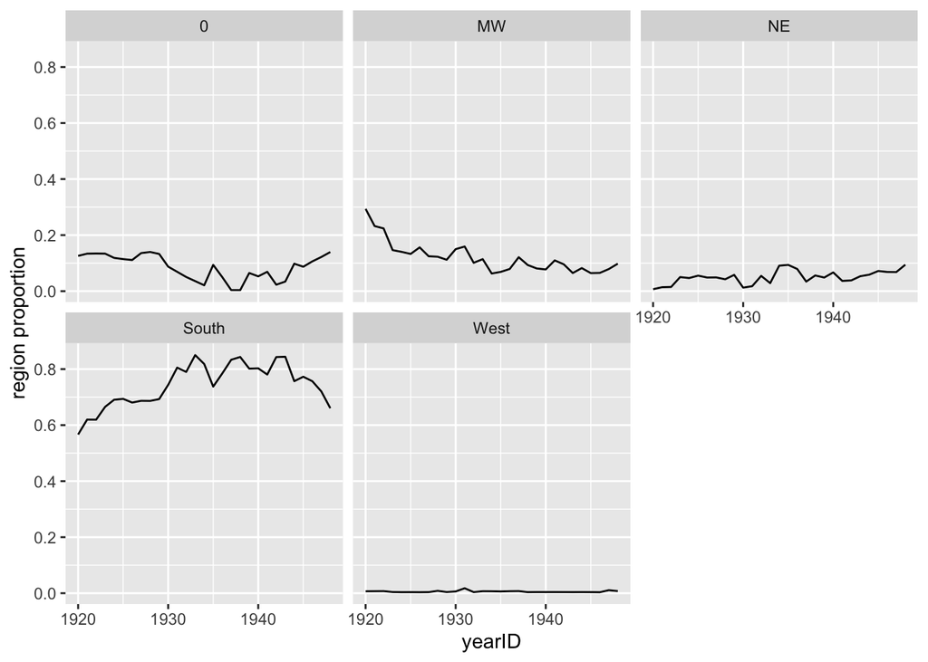

```r
## By region (0 is international)
ggplot(region_perc, aes(x = yearID, y = region_perc)) +
  geom_line() +
  facet_wrap(~region) +
  ylab("region proportion")
```

## South region population

```r
#https://www.census.gov/data/tables/time-series/dec/popchange-data-text.html
mat <- cbind(seq(1950,1920,by=-10),
             matrix(c(39477986, 35976777, 34427091, 29662053,
                      44460762, 40143332, 38594100, 34019792,
                      47197088, 41665901,   37857633, 33125803,
                      20189962, 14379119, 12323836, 9213920), ncol = 4))
df <- as.data.frame(mat)
colnames(df) <- c("year","NE","MW","South","W")
df$total <- rowSums(df[, 2:5])
```

## percent of age 20 to 29 negro males

```r
## 1920
## https://www2.census.gov/library/publications/decennial/1920/volume-2/41084484v2ch03.pdf
## page 14
negro1920 = 487169 + 424352

## 1930
## https://www2.census.gov/library/publications/decennial/1930/population-volume-2/16440598v2ch11.pdf
## page 18
negro1930 = 553622+500520

## 1940
## https://www2.census.gov/library/publications/decennial/1930/population-volume-2/16440598v2ch11.pdf
## page 9
negro1940 = 120615+117716+115437+111106+113876+118848+108433+107656+116749+106953

## 1950
## https://www2.census.gov/library/publications/decennial/1930/population-volume-2/16440598v2ch11.pdf
## page 1
negro1950 = 603511+622371
```

We now estimate the Negro League eligible population.

## Negro league eligible population

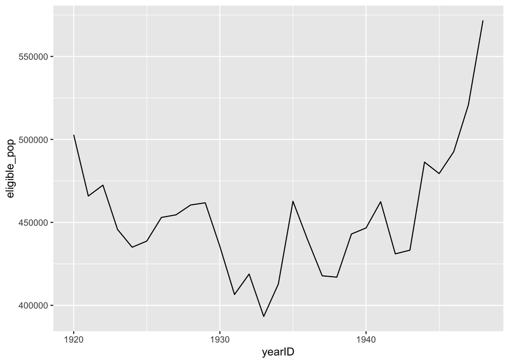

```r
df$eligible = c(negro1950, negro1940, negro1930, negro1920)
df_pop <- df %>% mutate(pop = South * eligible / total)
df_pop_long <- data.frame(yearID = 1920:1950,
                          pop = approx(df_pop$year, df_pop$pop, xout = 1920:1950)$y) %>%
  filter(yearID <= 1948)
region_perc_pop <- region_perc %>% filter(region == 'South') %>% left_join(df_pop_long) %>%
  mutate(eligible_pop = pop / region_perc)

ggplot(region_perc_pop, aes(x = yearID, y = eligible_pop)) +
  geom_line()
```